# Simpler single cell RNAseq data clustering

Liangtao Zheng and Xianwen Ren

BIOPIC, Peking University, Yiheyuan Road No. 5, Haidian District, Beijing, P. R. China

tao2013@gmail.com

2018-02-07

#### Abstract

Instructions on how to perform clustering using sscClust

#### Package

sscClust 0.1.0

# 1 Introduction

Simpler single cell RNAseq data clustering (`sscClust`) is a package implement the clustering pipeline for simple usage. The single cell RNAseq data clustering is usually consist of variable genes selection, dimension reduction, clustering on reduced data. Currently, this package also wrap other clustering method designed specifically for single cell RNAseq data, including `SC3`, `ZinbWave` etc.

# 2 data description

Here, we would use the Pollen dataset which is included in this package. This data set contains expression data of 249 cells by 6,982 gene, with eleven clusters corresponding to skin cells, pluripotent stem cells, blood cells, neural cells, etc. To calculate the ARI index and record the excuting time of functions, we also load two packages, *igraph* and *tictoc*.

```r
library("SingleCellExperiment")
library("sscClust")
library("igraph")
library("tictoc")
data("sce.Pollen")
sce.Pollen
```

```
## class: SingleCellExperiment
## dim: 6982 249
## metadata(0):
## assays(1): exprs
## rownames(6982): G1 G2 ... G6981 G6982
## rowData names(1): display.name
## colnames(249): S1 S2 ... S248 S249
## colData names(1): true_labs
## reducedDimNames(0):
## spikeNames(0):
```

# 3 Step by step usage

## 3.1 variable gene selection

We selected the top 1500 genes with higheast sd for clustering. There are many variable genes identification methods in the single cell RNAseq research community. For example, fit CV^2~mean relationship using a GLM model then the genes significantly higher than the fitted value are defined as highly variable genes. Here the sd method is sufficient.

```r
sce.Pollen <- ssc.variableGene(sce.Pollen,method="sd",sd.n=1500)
str(metadata(sce.Pollen)$ssc$variable.gene$sd)
```

```
##  chr [1:1500] "G5596" "G945" "G244" "G496" "G3558" "G5598" "G1909" ...
```

## 3.2 dimension reduction

Before clustering, we can use tSNE to visualize the expression profile of the data. This step also facilitate the selection of clustering parameters such number of clusters.

First, we perform PCA and keep only top PCs. By default, top 30 PCs will be kept. On the scree plot which dipict the variation exlained by each PC, `sscClust` can automatically find a knee point which can be used to set the number of PC to keep.

```r
sce.Pollen <- ssc.reduceDim(sce.Pollen,method="pca",seed = 9997)
```

```
## [2018-02-07 19:48:21] set.seed(9997) for ssc.reduceDim
```

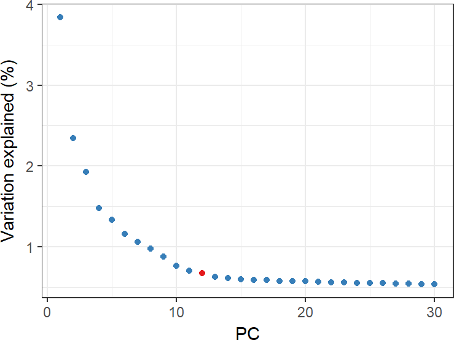

```r
ssc.plot.pca(sce.Pollen)
```

The scree plot suggest top 12 PCs should be kept. If the automatically selected knee point is not optimal, the `pca.npc` can be set explicitly.

```r
sce.Pollen <- ssc.reduceDim(sce.Pollen,method="pca",seed = 9997,pca.npc = 12)
```

```
## [2018-02-07 19:48:24] set.seed(9997) for ssc.reduceDim
```

By default, when PCA is finished, a t-SNE map is also generated internally. We can use `ssc.plot.tsne` to visualize the data.

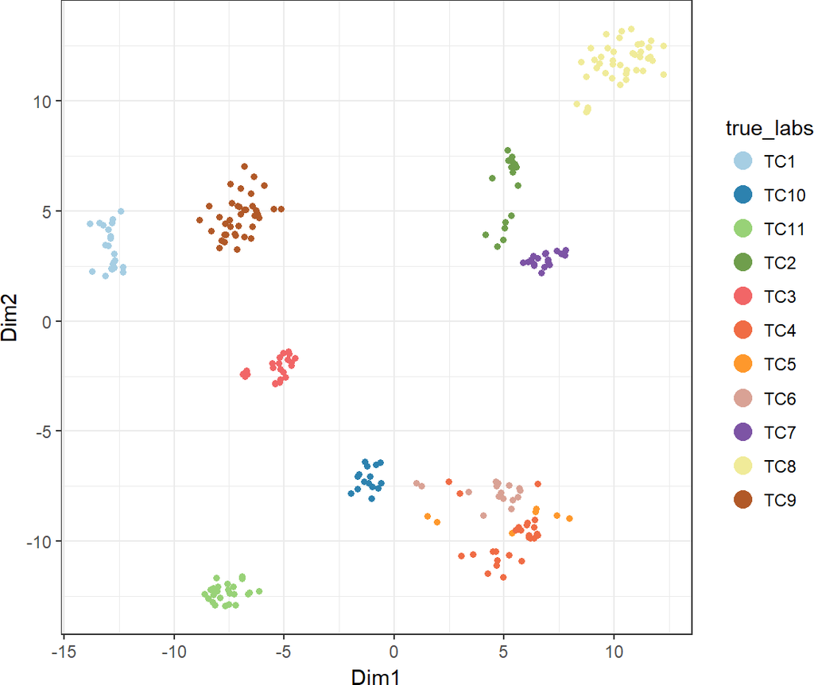

```r
ssc.plot.tsne(sce.Pollen,columns = "true_labs",reduced.name = "pca.tsne")
```

Note, a SingleCellExperiment object can contain multile reduced dimension respresentation of the data, which are stored in the reducedDim slot under different names. The reduced data by PCA is stored with name “pca”, and the automatically generated t-SNE map is stored with name “pca.tsne”.

## 3.3 clustering

We will use kmeans algorithm (implemented in function `ssc.clust`) to cluster the cells into 11 groups, and use the labels from original analysis of the dataset as true labels. The parameters `method` and `k.batch` is set to `kmeans` and `11` respectively. The dimension reduction by PCA has been done already, so `method.reduction` of `ssc.clust` is be `pca`:

```r
tic("clustering")
sce.Pollen <- ssc.clust(sce.Pollen, method.reduction="pca", method="kmeans", k.batch=11,seed = 9997)
```

```
## [2018-02-07 19:48:26] set.seed(9997) for ssc.clust
```

```r
toc()
```

```
## clustering: 0.05 sec elapsed
```

We can compare the clustering result with that of original study by ARI index:

```r
compare(as.factor(sce.Pollen$true_labs),
        as.factor(sce.Pollen$pca.kmeans.k11),
        method="adjusted.rand")
```

```
## [1] 0.9233418
```

Also we compare the clustering result by t-SNE:

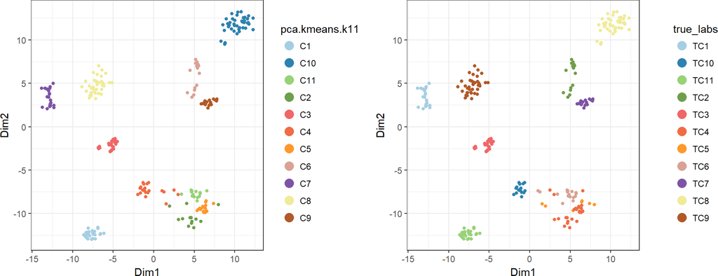

```r
ssc.plot.tsne(sce.Pollen,columns = c("pca.kmeans.k11","true_labs"),reduced.name = "pca.tsne")
```

# 4 All in One

We can run all the steps above in one step, using function `ssc.run`:

```r
sce.Pollen <- ssc.run(sce.Pollen,method.vgene = "sd",sd.n = 1500,method.reduction = "pca",method.clust = "kmeans", k.batch=11,seed = 9997)
```

```
## [2018-02-07 19:48:28] select variable genes ... (L1C1)
## [2018-02-07 19:48:29] reduce dimensions ... (L1C1)
## [2018-02-07 19:48:29] set.seed(9997) for ssc.reduceDim
##
## [2018-02-07 19:48:30] clustering ... (L1C1)
## [2018-02-07 19:48:30] set.seed(9997) for ssc.clust
```

## 4.1 various clustering pipelines

### 4.1.1 data transformation by spearman correlation, than kmeans clustering

```r
sce.Pollen <- ssc.run(sce.Pollen,method.vgene = "sd",sd.n = 1500,method.reduction = "iCor",method.clust = "kmeans", k.batch=11,seed = 9997)
```

```
## [2018-02-07 19:48:30] select variable genes ... (L1C1)
## [2018-02-07 19:48:30] reduce dimensions ... (L1C1)
## [2018-02-07 19:48:31] set.seed(9997) for ssc.reduceDim
##
## [2018-02-07 19:48:32] clustering ... (L1C1)
## [2018-02-07 19:48:32] set.seed(9997) for ssc.clust
```

```r
compare(as.factor(sce.Pollen$true_labs),
        as.factor(sce.Pollen$iCor.kmeans.k11),
        method="adjusted.rand")
```

```
## [1] 0.8767637
```

### 4.1.2 dimension reduction by pca, than clustering based on SNN

```r
sce.Pollen <- ssc.run(sce.Pollen,method.vgene = "sd",sd.n = 1500,method.reduction = "pca",
                      method.clust = "SNN", SNN.k=10,SNN.method="eigen",seed=9997)
```

```
## [2018-02-07 19:48:33] select variable genes ... (L1C1)
## [2018-02-07 19:48:33] reduce dimensions ... (L1C1)
## [2018-02-07 19:48:33] set.seed(9997) for ssc.reduceDim
##
## [2018-02-07 19:48:35] clustering ... (L1C1)
## [2018-02-07 19:48:35] set.seed(9997) for ssc.clust
##
## [2018-02-07 19:48:35] buildSNNGraph with k=10
##
## [2018-02-07 19:48:35] cluster using method eigen begin
##
## [2018-02-07 19:48:35] cluster using method eigen finished
```

```r
compare(as.factor(sce.Pollen$true_labs),
        as.factor(sce.Pollen$pca.SNN.kauto),
        method="adjusted.rand")
```

```
## [1] 0.8823326
```

### 4.1.3 dimension by pca and tSNE, run density based clustering on the tSNE map

Use ADPclust, automatically determine peaks

```r
sce.Pollen <- ssc.run(sce.Pollen,method.vgene = "sd",sd.n = 1500,method.reduction = "pca",
                      method.clust = "adpclust", seed=9997)
```

```
## [2018-02-07 19:48:35] select variable genes ... (L1C1)
## [2018-02-07 19:48:35] reduce dimensions ... (L1C1)
## [2018-02-07 19:48:35] set.seed(9997) for ssc.reduceDim
##
## [2018-02-07 19:48:37] clustering ... (L1C1)
## [2018-02-07 19:48:37] set.seed(9997) for ssc.clust
```

```r
compare(as.factor(sce.Pollen$true_labs),
        as.factor(sce.Pollen$pca.tsne.adpclust.kauto),
        method="adjusted.rand")
```

```
## [1] 0.611913
```

manually specified peaks

```r
sce.Pollen <- ssc.run(sce.Pollen,method.vgene = "sd",sd.n = 1500,method.reduction = "pca",
                      method.clust = "dpclust",
                      parfile = system.file("extdata/Pollen.par.r",package = "sscClust"),
                      out.prefix = "./Pollen.dpclust", seed=9997)
```

```
## parfile: E:/Program Files/Microsoft/R Open/R-3.4.2/library/sscClust/extdata/Pollen.par.r
## $L1C1
## $L1C1$delta
## [1] 3
##
## $L1C1$rho
## [1] 3
##
##
## $L1C1.de
## $L1C1.de$delta
## [1] 3
##
## $L1C1.de$rho
## [1] 3
##
##
## $L1C1.L2C1
## $L1C1.L2C1$k
## [1] 1
##
##
## $L1C1.L2C2
## $L1C1.L2C2$k
## [1] 1
##
##
## $L1C1.L2C3
## $L1C1.L2C3$k
## [1] 1
##
##
## $L1C1.L2C4
## $L1C1.L2C4$k
## [1] 1
##
##
## $L1C1.L2C6
## $L1C1.L2C6$k
## [1] 1
```

[output cut: 12 more lines]

```
## $L1C1.L2C9
## $L1C1.L2C9$k
## [1] 1
##
##
## [2018-02-07 19:48:38] select variable genes ... (L1C1)
## [2018-02-07 19:48:38] reduce dimensions ... (L1C1)
## [2018-02-07 19:48:38] set.seed(9997) for ssc.reduceDim
##
## [2018-02-07 19:48:39] clustering ... (L1C1)
## [2018-02-07 19:48:39] set.seed(9997) for ssc.clust
##
## Distance cutoff calculated to 0.5908042
## (dpclust.rho: 3.00)
## (dpclust.delta: 3.00)
```

```r
compare(as.factor(sce.Pollen$true_labs),
        as.factor(sce.Pollen$pca.tsne.dpclust.kauto),
        method="adjusted.rand")
```

```
## [1] 0.8874856
```

manually specified peaks, perform second round of clustering on C5:

```r
sce.Pollen <- ssc.run(sce.Pollen,method.vgene = "sd",sd.n = 1500,method.reduction = "pca",
                      method.clust = "dpclust",nIter = 2,
                      parfile = system.file("extdata/Pollen.par.r",package = "sscClust"),
                      out.prefix = "./Pollen.dpclust", seed=9997)
```

```
## parfile: E:/Program Files/Microsoft/R Open/R-3.4.2/library/sscClust/extdata/Pollen.par.r
## $L1C1
## $L1C1$delta
## [1] 3
##
## $L1C1$rho
## [1] 3
##
##
## $L1C1.de
## $L1C1.de$delta
## [1] 3
##
## $L1C1.de$rho
## [1] 3
##
##
## $L1C1.L2C1
## $L1C1.L2C1$k
## [1] 1
##
##
## $L1C1.L2C2
## $L1C1.L2C2$k
## [1] 1
##
##
## $L1C1.L2C3
## $L1C1.L2C3$k
## [1] 1
##
##
## $L1C1.L2C4
## $L1C1.L2C4$k
## [1] 1
##
##
## $L1C1.L2C6
## $L1C1.L2C6$k
## [1] 1
```

[output cut: 12 more lines]

```
## $L1C1.L2C9
## $L1C1.L2C9$k
## [1] 1
##
##
## [2018-02-07 19:48:41] select variable genes ... (L1C1)
## [2018-02-07 19:48:42] reduce dimensions ... (L1C1)
## [2018-02-07 19:48:42] set.seed(9997) for ssc.reduceDim
##
## [2018-02-07 19:48:43] clustering ... (L1C1)
## [2018-02-07 19:48:43] set.seed(9997) for ssc.clust
##
## Distance cutoff calculated to 0.5908042
## (dpclust.rho: 3.00)
## (dpclust.delta: 3.00)
```

```
## [2018-02-07 19:48:45] select variable genes ... (L1C1.L2C5)
## [2018-02-07 19:48:45] reduce dimensions ... (L1C1.L2C5)
## [2018-02-07 19:48:45] set.seed(9997) for ssc.reduceDim
##
## [2018-02-07 19:48:45] clustering ... (L1C1.L2C5)
## [2018-02-07 19:48:45] set.seed(9997) for ssc.clust
##
## Distance cutoff calculated to 4.659483
## (dpclust.rho: 0.79)
## (dpclust.delta: 54.47)
```

```r
compare(as.factor(sce.Pollen$true_labs),
        as.factor(sce.Pollen$pca.tsne.dpclust.kauto),
        method="adjusted.rand")
```

```
## [1] 0.9360301
```

### 4.1.4 wrapper for SC3:

```r
sce.Pollen <- ssc.run(sce.Pollen,method.vgene = "sd",sd.n = 1500,k.batch = 9:13,method.clust = "SC3",seed=9997)
```

```
## [2018-02-07 19:48:46] select variable genes ... (L1C1)
## [2018-02-07 19:48:46] reduce dimensions ... (L1C1)
## [2018-02-07 19:48:47] set.seed(9997) for ssc.reduceDim
##
## [2018-02-07 19:48:48] clustering ... (L1C1)
## [2018-02-07 19:48:48] set.seed(9997) for ssc.clust
```

```
## Setting SC3 parameters...
```

```
## Calculating distances between the cells...
```

```
## Performing transformations and calculating eigenvectors...
```

```
## Performing k-means clustering...
```

```
## Calculating consensus matrix...
```

```
## Calculating biology...
```

```r
compare(as.factor(sce.Pollen$true_labs),
        as.factor(sce.Pollen$sc3_11_clusters),
        method="adjusted.rand")
```

```
## [1] 0.9398187
```

### 4.1.5 visualize the result from various methods

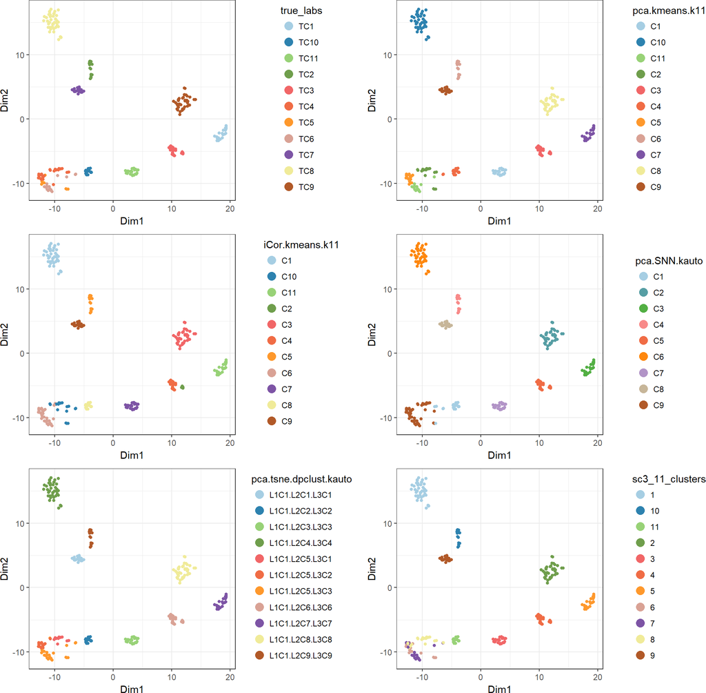

```r
ssc.plot.tsne(sce.Pollen,columns = c("true_labs","pca.kmeans.k11",
                                     "iCor.kmeans.k11","pca.SNN.kauto",
                                     "pca.tsne.dpclust.kauto","sc3_11_clusters"),reduced.name = "pca.tsne")
```